# MidtermProject

# Linear Regression

```python
trainLR =pd.DataFrame({"AvgFlr": train["AvgFlr"]})
```

```python
trainLR.shape
```

```
(1460, 1)
```

```python
trainLR
```

| Id | AvgFlr |
| --- | --- |
| 1 | 855.0 |
| 2 | 631.0 |
| 3 | 893.0 |
| 4 | 858.5 |
| 5 | 1099.0 |
| ... | ... |
| 1456 | 823.5 |
| 1457 | 1036.5 |
| 1458 | 1170.0 |
| 1459 | 539.0 |
| 1460 | 628.0 |

1460 rows × 1 columns

```python
trainLR.describe()
```

|  | AvgFlr |
| --- | --- |
| count | 1460.000000 |
| mean | 754.809589 |
| std | 260.581761 |
| min | 167.000000 |
| 25% | 561.875000 |
| 50% | 729.000000 |
| 75% | 887.625000 |
| max | 2821.000000 |

```python
from sklearn.model_selection import train_test_split
from sklearn.linear_model import LinearRegression
X = trainLR.values.reshape(-1,1)
y = trainSP.values.reshape(-1,1)

X_train, X_test, y_train, y_test = train_test_split(X,y,test_size = 0.25,random_state=9)
linreg = LinearRegression().fit(X_train,y_train)
```

```python
print(linreg.intercept_)
print(linreg.coef_)
```

```
[20184.91147007]
[[211.83937376]]
```

```python
y_pred = linreg.predict(X_test)
#y_pred
```

```python
df1 = pd.DataFrame({'Actual':y_test.flatten(),'Predicted': y_pred.flatten()})
df1
```

|  | Actual | Predicted |
| --- | --- | --- |
| 0 | 151400 | 287208.442096 |
| 1 | 241500 | 164553.444688 |
| 2 | 82000 | 142204.390756 |
| 3 | 162000 | 147712.214474 |
| 4 | 140000 | 165824.480931 |
| ... | ... | ... |
| 360 | 176000 | 140615.595453 |
| 361 | 85500 | 112229.119369 |
| 362 | 79000 | 102166.749116 |
| 363 | 163990 | 174403.975568 |
| 364 | 174000 | 182983.470205 |

365 rows × 2 columns

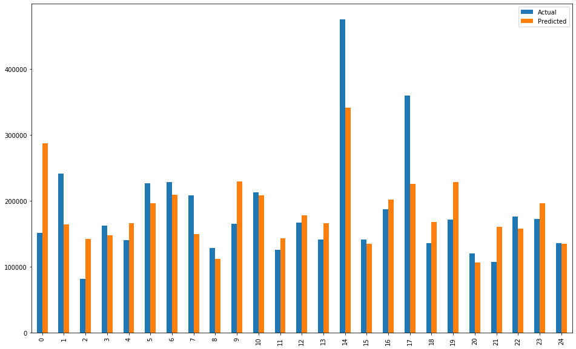

```python
df1head = df1.head(25)
df1head.plot(kind='bar',figsize=(16,10))
plt.show()
```

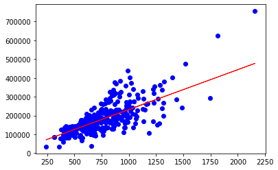

```python
plt.scatter(X_test,y_test,color="blue")
plt.plot(X_test,y_pred,color='red',linewidth=1)
plt.show()
```

```python
from sklearn import metrics
print('Mean Absolute Error:', metrics.mean_absolute_error(y_test, y_pred))
print('Mean Squared Error:', metrics.mean_squared_error(y_test, y_pred))
print('Root Mean Squared Error:', np.sqrt(metrics.mean_squared_error(y_test, y_pred)))
print('R-squared Error:', metrics.r2_score(y_test, y_pred))
```

```
Mean Absolute Error: 36518.168247191315
Mean Squared Error: 2843124960.2744913
Root Mean Squared Error: 53320.961734335695
R-squared Error: 0.55874675395604
```

### Analysis

My first machine learning algorithm that I implemented was linear regression. For this model I used the feature of average floor. I chose this feature first because it was the feature that had the most importance and also it was the feature that I created by take the average of the two floor features given. I believed that the average floor was important and strong enough to be able to predict the values of sales price. The results of the data weren't so great. There were times when the data seemed like they data was predicted pretty well, but there were times where it was way off. Thats why it seems that the mean absoulte error, mean squared error, and root mean squared error is so high. The r squared error, which represents the coefficient of how well the values fit compared to the original values, is a little bit over 50%. Which supports what I stated before, where some predictions were spot on and other times way off.

# KNN

```python
trainKNN = pd.DataFrame({"GarageArea": train["GarageArea"], "LotArea": train["LotArea"]})
trainKNN
```

| Id | GarageArea | LotArea |
| --- | --- | --- |
| 1 | 548 | 8450 |
| 2 | 460 | 9600 |
| 3 | 608 | 11250 |
| 4 | 642 | 9550 |
| 5 | 836 | 14260 |
| ... | ... | ... |
| 1456 | 460 | 7917 |
| 1457 | 500 | 13175 |
| 1458 | 252 | 9042 |
| 1459 | 240 | 9717 |
| 1460 | 276 | 9937 |

1460 rows × 2 columns

```python
trainKNN.shape
```

```
(1460, 2)
```

```python
trainSP.shape
```

```
(1460,)
```

```python
trainKNN.describe()
```

|  | GarageArea | LotArea |
| --- | --- | --- |
| count | 1460.000000 | 1460.000000 |
| mean | 472.980137 | 10516.828082 |
| std | 213.804841 | 9981.264932 |
| min | 0.000000 | 1300.000000 |
| 25% | 334.500000 | 7553.500000 |
| 50% | 480.000000 | 9478.500000 |
| 75% | 576.000000 | 11601.500000 |
| max | 1418.000000 | 215245.000000 |

```python
trainKNN.head()
```

| Id | GarageArea | LotArea |
| --- | --- | --- |
| 1 | 548 | 8450 |
| 2 | 460 | 9600 |
| 3 | 608 | 11250 |
| 4 | 642 | 9550 |
| 5 | 836 | 14260 |

```python
X = np.array(trainKNN)
X
```

```
array([[  548,  8450],
       [  460,  9600],
       [  608, 11250],
       ...,
       [  252,  9042],
       [  240,  9717],
       [  276,  9937]], dtype=int64)
```

```python
trainSP.mean()
```

```
180921.19589041095
```

```python
y = np.array(trainSP)
y
```

```
array([208500, 181500, 223500, ..., 266500, 142125, 147500], dtype=int64)
```

```python
y = np.where(y >= y.mean(), 1 , 0)
Counter(y)
```

```
Counter({1: 560, 0: 900})
```

```python
trainSP.shape
```

```
(1460,)
```

```python
from sklearn import metrics, neighbors, preprocessing, model_selection
X_train, X_test, y_train, y_test = model_selection.train_test_split(X, y, test_size=0.25)
knn = neighbors.KNeighborsClassifier()
knn.fit(X_train, y_train)
```

```
KNeighborsClassifier(algorithm='auto', leaf_size=30, metric='minkowski',
                     metric_params=None, n_jobs=None, n_neighbors=5, p=2,
                     weights='uniform')
```

```python
accuracy = knn.score(X_test, y_test)
accuracy
```

```
0.7287671232876712
```

```python
from sklearn.metrics import confusion_matrix
pred=knn.predict(X_test)
cm = confusion_matrix(y_test, pred)
cm
```

```
array([[186,  44],
       [ 55,  80]], dtype=int64)
```

```python
knn.score(X_test, y_test)
```

```
0.7287671232876712
```

```python
from sklearn.metrics import classification_report
print(classification_report(y_test,pred))
```

```
              precision    recall  f1-score   support

           0       0.77      0.81      0.79       230
           1       0.65      0.59      0.62       135

    accuracy                           0.73       365
   macro avg       0.71      0.70      0.70       365
weighted avg       0.72      0.73      0.73       365
```

```python
from sklearn.neighbors import KNeighborsClassifier

n = np.arange(1,9)
train_accuracy =np.empty(len(n))
test_accuracy = np.empty(len(n))

for i,k in enumerate(n):
    knn = KNeighborsClassifier(n_neighbors=k)
    knn.fit(X_train, y_train)
    train_accuracy[i] = knn.score(X_train, y_train)
    test_accuracy[i] = knn.score(X_test, y_test)
```

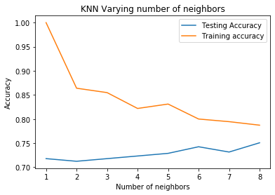

```python
plt.title('KNN Varying number of neighbors')
plt.plot(n, test_accuracy, label='Testing Accuracy')
plt.plot(n, train_accuracy, label='Training accuracy')
plt.legend()
plt.xlabel('Number of neighbors')
plt.ylabel('Accuracy')
plt.show()
```